# Project Report - Practical Machine Learning

Shriram Gajjar

2016-03-23

This works is prepared as a partial fulfillment of Coursera’s MOOC Practical Machine Learning from Johns Hopkins University. For more information about the several MOOCs comprised in this Specialization, please visit: https://www.coursera.org/specialization/jhudatascience/

GitHub repo: https://github.com/5hri/MLcoursera

RPubs: http://rpubs.com/shri/66501

## Background Introduction

Using devices such as Jawbone Up, Nike FuelBand, and Fitbit it is now possible to collect a large amount of data about personal activity relatively inexpensively. These type of devices are part of the quantified self movement - a group of enthusiasts who take measurements about themselves regularly to improve their health, to find patterns in their behavior, or because they are tech geeks. One thing that people regularly do is quantify how much of a particular activity they do, but they rarely quantify how well they do it. In this project, the goal will be to use data from accelerometers on the belt, forearm, arm, and dumbell of 6 participants. They were asked to perform barbell lifts correctly and incorrectly in 5 different ways. More information is available from the website here: http://groupware.les.inf.puc-rio.br/har (see the section on the Weight Lifting Exercise Dataset).

## Data Sources

The training data used for this project is available here:

https://d396qusza40orc.cloudfront.net/predmachlearn/pml-training.csv

The test data used is available here:

https://d396qusza40orc.cloudfront.net/predmachlearn/pml-testing.csv

The data for this project come from this source: [http://groupware.les.inf.puc-rio.br/har]. If you use the document you create for this class for any purpose please cite them as they have been very generous in allowing their data to be used for this kind of assignment.

## Project Intended Results

The goal of your project is to predict the manner in which they did the exercise. This is the “classe” variable in the training set. Use any of the other variables to predict with. Create a report describing how the model was built, how cross validation was used, the expected out of sample error, and justify the choices made. Finally, use the prediction model to predict 20 different test cases.

1. Submission should consist of a link to a Github repo with your R markdown and compiled HTML file describing analysis
2. Submit predictions in appropriate format

## Reproduceablity

An overall pseudo-random number generator seed was set at 12345 for all code. In order to reproduce the results below, the same seed should be used. Different packages were downloaded and installed, such as caret and randomForest. These should also be installed in order to reproduce the results below (please see code below for ways and syntax to do so).

*Note:To install, for instance, the caret package in R, run this command: install.packages(“caret”)

Finally, load the same seed with the following line of code:

```r
set.seed(12345)
```

The following Libraries were used for this project:

```r
library(caret)
```

```r
library(rpart)
library(rpart.plot)
library(RColorBrewer)
library(rattle)
library(randomForest)
```

## How the model was built

Our outcome variable is classe, a factor variable with 5 levels. For this data set, “participants were asked to perform one set of 10 repetitions of the Unilateral Dumbbell Biceps Curl in 5 different fashions:

- exactly according to the specification (Class A)
- throwing the elbows to the front (Class B)
- lifting the dumbbell only halfway (Class C)
- lowering the dumbbell only halfway (Class D)
- throwing the hips to the front (Class E)

Class A corresponds to the specified execution of the exercise, while the other 4 classes correspond to common mistakes.

Prediction evaluations will be based on maximizing the accuracy and minimizing the out-of-sample error. All other available variables after cleaning will be used for prediction. Two models will be tested using decision tree and random forest algorithms. The model with the highest accuracy will be chosen as our final model.

## Cross-validation

Cross-validation will be performed by subsampling our training data set randomly without replacement into 2 subsamples: subTraining data (75% of the original Training data set) and subTesting data (25%). Our models will be fitted on the subTraining data set, and tested on the subTesting data. Once the most accurate model is choosen, it will be tested on the original Testing data set.

## Expected out-of-sample error

The expected out-of-sample error will correspond to the quantity: 1-accuracy in the cross-validation data. Accuracy is the proportion of correct classified observation over the total sample in the subTesting data set. Expected accuracy is the expected accuracy in the out-of-sample data set (i.e. original testing data set). Thus, the expected value of the out-of-sample error will correspond to the expected number of missclassified observations/total observations in the Test data set, which is the quantity: 1-accuracy found from the cross-validation data set.

## Reasons for my choices

Our outcome variable “classe” is an unordered factor variable. Thus, we can choose our error type as 1-accuracy. We have a large sample size with N= 19622 in the Training data set. Features with all missing values will be discarded as well as features that are irrelevant. All other features will be kept as relevant variables. Decision tree and random forest algorithms are known for their ability of detecting the features that are important for classification. Feature selection is inherent, so it is not so necessary at the data preparation phase. Thus, there won’t be any feature selection section in this report.

## Getting the data

-Some missing values are coded as string “#DIV/0!” or “” or “NA” - these will be changed to NA. -I noticed that both data sets contain columns with all missing values - these will be deleted.  
-Loading the training data set into my R session replacing all missing with “NA”

```r
trainset <-read.csv("C:/Users/sggajjar/Documents/R/Mach_learning_coursera/pml-training.csv",na.strings=c("NA","#DIV/0!",""))

#The testing data set can be found on the following URL:
testset <-read.csv("C:/Users/sggajjar/Documents/R/Mach_learning_coursera/pml-testing.csv", na.strings=c("NA","#DIV/0!", ""))

# Check dimensions for number of variables and number of observations
dim(trainset)
```

```
## [1] 19622   160
```

```r
dim(testset)
```

```
## [1]  20 160
```

```r
# Delete columns with all missing values
trainset<-trainset[,colSums(is.na(trainset)) == 0]
testset <-testset[,colSums(is.na(testset)) == 0]

# Some variables are irrelevant to our current project: user_name, raw_timestamp_part_1, raw_timestamp_part_,2 cvtd_timestamp, new_window, and  num_window (columns 1 to 7). We can delete these variables.
trainset   <-trainset[,-c(1:7)]
testset <-testset[,-c(1:7)]

# I like to look at dim of datasets to have an idea of the size of data I am dealing with:
dim(trainset)
```

```
## [1] 19622    53
```

```r
dim(testset)
```

```
## [1] 20 53
```

```r
head(trainset)
```

```
##   roll_belt pitch_belt yaw_belt total_accel_belt gyros_belt_x gyros_belt_y
## 1      1.41       8.07    -94.4                3         0.00         0.00
## 2      1.41       8.07    -94.4                3         0.02         0.00
## 3      1.42       8.07    -94.4                3         0.00         0.00
## 4      1.48       8.05    -94.4                3         0.02         0.00
## 5      1.48       8.07    -94.4                3         0.02         0.02
## 6      1.45       8.06    -94.4                3         0.02         0.00
##   gyros_belt_z accel_belt_x accel_belt_y accel_belt_z magnet_belt_x
## 1        -0.02          -21            4           22            -3
## 2        -0.02          -22            4           22            -7
## 3        -0.02          -20            5           23            -2
## 4        -0.03          -22            3           21            -6
## 5        -0.02          -21            2           24            -6
## 6        -0.02          -21            4           21             0
##   magnet_belt_y magnet_belt_z roll_arm pitch_arm yaw_arm total_accel_arm
```

[output cut: 69 more lines]

```r
head(testset)
```

```
##   roll_belt pitch_belt yaw_belt total_accel_belt gyros_belt_x gyros_belt_y
## 1    123.00      27.00    -4.75               20        -0.50        -0.02
## 2      1.02       4.87   -88.90                4        -0.06        -0.02
## 3      0.87       1.82   -88.50                5         0.05         0.02
## 4    125.00     -41.60   162.00               17         0.11         0.11
## 5      1.35       3.33   -88.60                3         0.03         0.02
## 6     -5.92       1.59   -87.70                4         0.10         0.05
##   gyros_belt_z accel_belt_x accel_belt_y accel_belt_z magnet_belt_x
## 1        -0.46          -38           69         -179           -13
## 2        -0.07          -13           11           39            43
## 3         0.03            1           -1           49            29
## 4        -0.16           46           45         -156           169
## 5         0.00           -8            4           27            33
## 6        -0.13          -11          -16           38            31
##   magnet_belt_y magnet_belt_z roll_arm pitch_arm yaw_arm total_accel_arm
```

[output cut: 69 more lines]

## Partioning the training set into two

The training data set contains 53 variables and 19622 obs. The testing data set contains 53 variables and 20 obs. In order to perform cross-validation, the training data set is partionned into 2 sets: mytrain (75%) and mytest (25%). This will be performed using random subsampling without replacement.

```r
inTrain <- createDataPartition(y=trainset$classe, p=0.75, list=FALSE)
mytrain <- trainset[inTrain, ];
mytest <- trainset[-inTrain, ]

dim(mytrain);
```

```
## [1] 14718    53
```

```r
dim(mytest);
```

```
## [1] 4904   53
```

## Visualizing the data

A plot of the outcome variable will allow us to see the frequency of each levels in the subTraining data set and compare one another. The variable “classe” contains 5 levels: A, B, C, D and E.

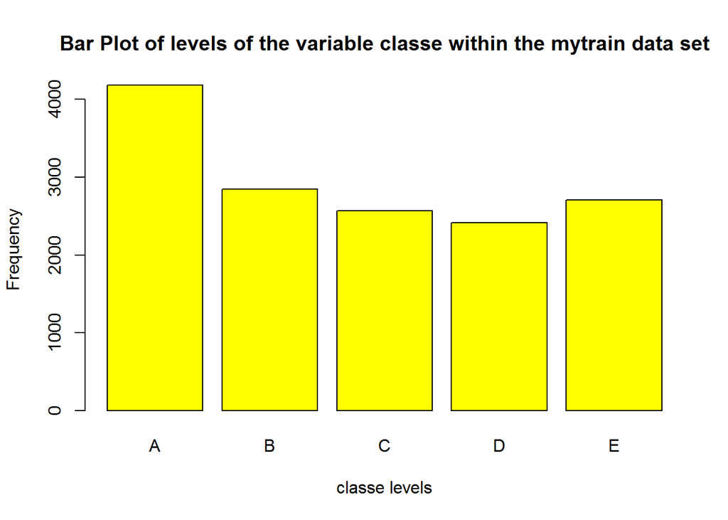

```r
plot(mytrain$classe, col="yellow", main="Bar Plot of levels of the variable classe within the mytrain data set", xlab="classe levels", ylab="Frequency")
```

From the graph above, we can see that each level frequency is within the same order of magnitude of each other. Level A is the most frequent with more than 4000 occurrences while level D is the least frequent with about 2500 occurrences.

## Using ML algorithms for prediction: Decision Tree

```r
modFit1 <- rpart(classe ~ ., data=mytrain, method="class")
```

Note: to view the decision tree with fancy run this command:

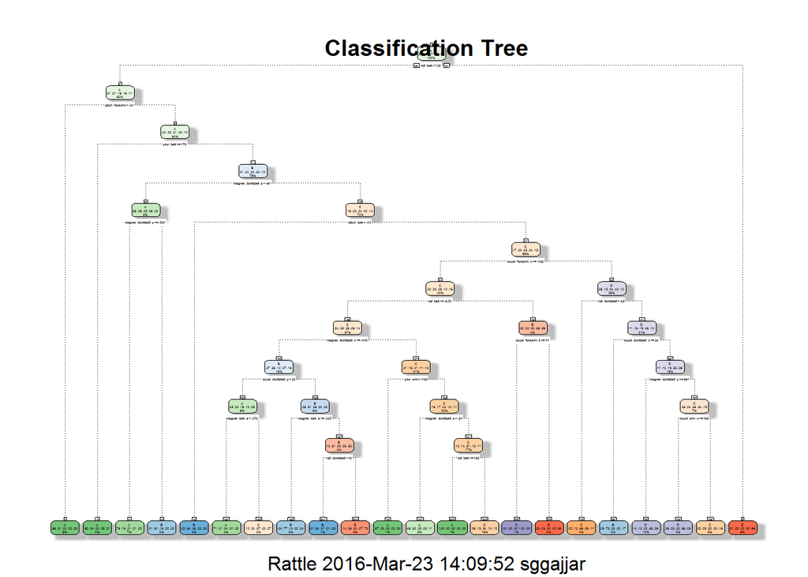

```r
fancyRpartPlot(modFit1,main="Classification Tree")
```

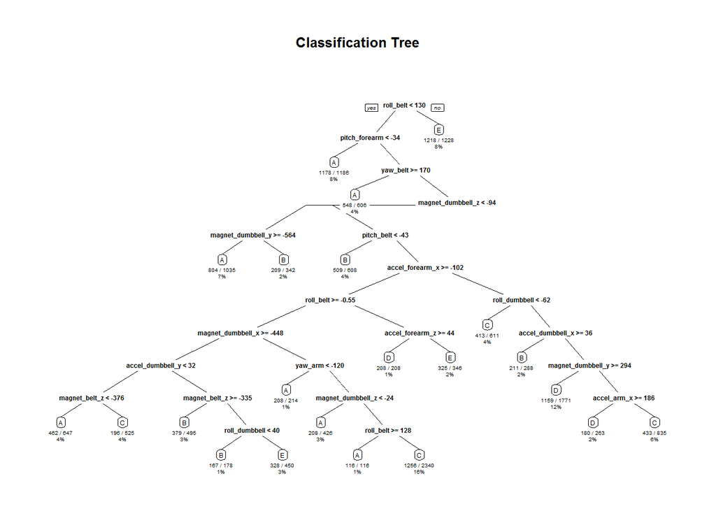

```r
rpart.plot(modFit1,main="Classification Tree",extra=102, under=TRUE, faclen=0)
```

Predicting:

```r
predictions1 <- predict(modFit1, mytest, type = "class")
```

# Test results on our subTesting data set:

```r
confusionMatrix(predictions1, mytest$classe)
```

```
## Confusion Matrix and Statistics
##
##           Reference
## Prediction    A    B    C    D    E
##          A 1180  174   20   30   38
##          B   15  475   61   39   33
##          C   72  213  761  212  187
##          D   97   77   13  506   36
##          E   31   10    0   17  607
##
## Overall Statistics
##
##                Accuracy : 0.7196
##                  95% CI : (0.7068, 0.7322)
##     No Information Rate : 0.2845
##     P-Value [Acc > NIR] : < 2.2e-16
##
##                   Kappa : 0.6456
##  Mcnemar's Test P-Value : < 2.2e-16
##
## Statistics by Class:
##
##                      Class: A Class: B Class: C Class: D Class: E
## Sensitivity            0.8459  0.50053   0.8901   0.6294   0.6737
## Specificity            0.9253  0.96258   0.8311   0.9456   0.9855
## Pos Pred Value         0.8183  0.76244   0.5266   0.6941   0.9128
## Neg Pred Value         0.9379  0.88928   0.9728   0.9286   0.9306
## Prevalence             0.2845  0.19352   0.1743   0.1639   0.1837
## Detection Rate         0.2406  0.09686   0.1552   0.1032   0.1238
## Detection Prevalence   0.2940  0.12704   0.2947   0.1487   0.1356
## Balanced Accuracy      0.8856  0.73155   0.8606   0.7875   0.8296
```

## Using ML algorithms for prediction: Random Forests

```r
modFit2 <- randomForest(classe ~. , data=mytrain)
```

Predicting:

```r
predictions2 <- predict(modFit2, mytest, type = "class")
```

(Moment of truth) Using confusion Matrix to test results:

```r
confusionMatrix(predictions2, mytest$classe)
```

```
## Confusion Matrix and Statistics
##
##           Reference
## Prediction    A    B    C    D    E
##          A 1395    9    0    0    0
##          B    0  936    1    0    0
##          C    0    4  853    6    1
##          D    0    0    1  798    0
##          E    0    0    0    0  900
##
## Overall Statistics
##
##                Accuracy : 0.9955
##                  95% CI : (0.9932, 0.9972)
##     No Information Rate : 0.2845
##     P-Value [Acc > NIR] : < 2.2e-16
##
##                   Kappa : 0.9943
##  Mcnemar's Test P-Value : NA
##
## Statistics by Class:
##
##                      Class: A Class: B Class: C Class: D Class: E
## Sensitivity            1.0000   0.9863   0.9977   0.9925   0.9989
## Specificity            0.9974   0.9997   0.9973   0.9998   1.0000
## Pos Pred Value         0.9936   0.9989   0.9873   0.9987   1.0000
## Neg Pred Value         1.0000   0.9967   0.9995   0.9985   0.9998
## Prevalence             0.2845   0.1935   0.1743   0.1639   0.1837
## Detection Rate         0.2845   0.1909   0.1739   0.1627   0.1835
## Detection Prevalence   0.2863   0.1911   0.1762   0.1629   0.1835
## Balanced Accuracy      0.9987   0.9930   0.9975   0.9961   0.9994
```

Random Forests yielded better Results, as expected!

## Generating Files to submit as answers for the Assignment:

Finally, using the provided Test Set:

For Random Forests is, which yielded a much better prediction:

```r
predictfinal <- predict(modFit2, testset, type = "class")
```

## Function to generate files with predictions to submit for assignment

```r
pml_write_files = function(x){
  n = length(x)
  for(i in 1:n){
    filename = paste0("problem_id_",i,".txt")
    write.table(x[i],file=filename,quote=FALSE,row.names=FALSE,col.names=FALSE)
  }
}

pml_write_files(predictfinal)
```